# Homework4–Qingqing Xu

```r
library(tidyverse)
library(stringr)
require(readr)
library(data.table)
library(readxl)
```

1.Questions in R for Data Science Chapter 14

14.2.5 Exercise

1.The difference between paste() and paste0() is that paste() separates strings by spaces by default while paste0() does not.The related string function to paste() is str_c(…,set=“”). The related string function to paste0() is str_c(). The str_c and the paste function differ in handling of NA.The str_c function returns NA if there is any NA in the argument. We need to use str_replace_na() to print as “NA”. The paste functions convert NA to character “NA” and then concatenate. The paste function uses str_replace_na by default.

2.The collapse function comines a vector of strings into a single string. The sep function is to insert between input vectors.

3.Use str_length() and str_sub() to extract the middle character from a string. I will print the two middle characters if the string has an even number of characters to give the user the choice to pick the one they need.

```r
extract_middle <- function(x){
  L <- str_length(x)
  l <- length(L)
  res <- c()
  y <- vector(mode="character", length=l)
  i=1
  while (i<=l) {
  if (L[i] %% 2 ==0)
  y[i] <- str_sub(x[i], L[i]/2, L[i]/2+1)
else
  y[i] <- str_sub(x[i], L[i]/2+0.5, L[i]/2+0.5)
 res <- c(res,y[i])
 i=i+1
  }
  res
}

x <- c("a", "abc", "abcd", "abcde", "abcdef")
extract_middle(x)
```

```
## [1] "a"  "b"  "bc" "c"  "cd"
```

4.The str_wrap() formats paragraphs. I might want to use it for wrapping long strings of text to be easy-to-read.

5.str_trim() trims whitespace from start and end of string. The opposite of str_trim() is str_pad() which pads a string to a certain length with another string.

6.A function that turns (e.g.) a vector c(“a”, “b”, “c”) into the string a, b, and c.

```r
vec_str <- function(x, sep = ", ", and = ", and ") {
  if (length(x) > 1) {
    if (length(x) == 2)
    str_c(str_c(x[-length(x)], x[length(x)],sep=" and "))
    else
    str_c(str_c(x[-length(x)], collapse = sep),
                x[length(x)],
                sep = and)
    }
  else {
    x
  }
}

vec_str(c("a", "b", "c"))
```

```
## [1] "a, b, and c"
```

```r
vec_str("")
```

```
## [1] ""
```

```r
vec_str("a")
```

```
## [1] "a"
```

```r
vec_str(c("a", "b"))
```

```
## [1] "a and b"
```

14.3.1.1 Exercise

2.I would match the sequence “’ by doing:

```r
x = "\"'\\"
writeLines(x)
```

```
## "'\
```

```r
str_view(x, "\\\"'\\\\")
```

[interactive chart not shown]

3.regular expression ...... match patterns .a.b.c

```r
str <- ".a.b.c"
str_view(str, pattern = "\\..\\..\\..")
```

[interactive chart not shown]

14.3.2.1 Exercises

1.I would match the literal string “$^$ using:

```r
str <- "$^$"
str_view(str, "\\$\\^\\$")
```

[interactive chart not shown]

2.Create regular expressions that find all words that:

```r
str_view(words, "^y",match=TRUE) #Start with “y”
```

[interactive chart not shown]

```r
str_view(words, "x$",match=TRUE) #End with “x”
```

[interactive chart not shown]

```r
str_view(words, "^...$",match=TRUE) #Are exactly three letters long
```

[interactive chart not shown]

```r
str_view(words, ".......",match=TRUE) #Have seven letters or more
```

[interactive chart not shown]

14.3.3.1 Exercises

1.Create regular expressions to find all words that:

```r
str_view(words, "^[aeiou]",match=TRUE) #Start with a vowel.
```

[interactive chart not shown]

```r
str_view(words, "^[^aeiou]*$",match=TRUE) #That only contain consonants. (Hint: thinking about matching “not”-vowels.)
```

[interactive chart not shown]

```r
str_view(words, "[^e]ed$", match = T) #End with ed, but not with eed.
```

[interactive chart not shown]

```r
str_view(words, "i(ng|se)$", match = T) #End with ing or ise.
```

[interactive chart not shown]

2.Empirically verify the rule “i before e except after c”.

```r
str_view(words, "([^c]|)ei", match = T)
```

[interactive chart not shown]

3.Yes

```r
str_view(words, "q[^u]", match = T)
```

[interactive chart not shown]

4.Write a regular expression that matches a word if it’s probably written in British English, not American English. Since British and American spelling are different in many ways, I give an example that “Verbs in British English that can be spelled with either -ize or -ise at the end are always spelled with -ize at the end in American English”:

```r
str_view(words, "ise", match = T)
```

[interactive chart not shown]

5.Create a regular expression that will match telephone numbers as commonly written in my country.

```r
phone_numbers <- c("(0086)-15267807935","(209)-123-4567")
str_view(phone_numbers, "^\\(\\d{3}\\)-\\d{3}-\\d{4}",match=TRUE)
```

[interactive chart not shown]

14.3.4.1 Exercises

1.The equivalents of ? in {m,n} form is {0,1}.The equivalents of + in {m,n} form is {1,}. The equivalents of * in {m,n} form is {0,}

3.Create regular expressions to find all words that:

```r
str_view(words, "^[^aeiou]{3}", match = T) #Start with three consonants
```

[interactive chart not shown]

```r
str_view(words, "[aeiou]{3,}", match = T) #Have three or more vowels in a row.
```

[interactive chart not shown]

```r
str_view(words, "([aeiou][^aeiou]){2,}", match = T) #Have two or more vowel-consonant pairs in a row.
```

[interactive chart not shown]

14.3.5.1 Exercises

1.Describe, in words, what these expressions will match:

```r
str_view(words, "(.)\\1\\1", match = TRUE) #find words that have 3 same letters in a row
```

[interactive chart not shown]

```r
str_view(words, "(.)(.)\\2\\1", match = TRUE) # find words that have a 4 letter pattern symmetrical with first 2 and last 2
```

[interactive chart not shown]

```r
str_view(words, "(..)\\1", match = TRUE) #find words that have a repeated pair of letters.
```

[interactive chart not shown]

```r
str_view(words, "(.).\\1.\\1", match = TRUE) #1st 3rd and 5th letters are same
```

[interactive chart not shown]

```r
str_view(words, "(.)(.)(.).*\\3\\2\\1", match = TRUE) #last three letters are reversed of ths first 3
```

[interactive chart not shown]

2.Construct regular expressions to match words that:

```r
str_view(words, "^(.).*\\1$", match = T) #Start and end with the same character
```

[interactive chart not shown]

```r
str_view(words, "(..).*\\1", match = T) #Contain a repeated pair of letters (e.g. “church” contains “ch” repeated twice.)
```

[interactive chart not shown]

```r
str_view(words, "(.).*\\1.*\\1", match = T) #Contain one letter repeated in at least three places (e.g. “eleven” contains three “e”s.)
```

[interactive chart not shown]

14.4.2 Exercises

1.Try solving it by using both a single regular expression, and a combination of multiple str_detect() calls.

```r
#Find all words that start or end with x.
str_view(words, "^x|x$", match = TRUE)
```

[interactive chart not shown]

```r
words[str_detect(words, "^x") | str_detect(words, "x$")]
```

```
## [1] "box" "sex" "six" "tax"
```

```r
#Find all words that start with a vowel and end with a consonant.
str_view(words, "^[aeiou].*[^aeoui]$", match = TRUE)
```

[interactive chart not shown]

```r
words[str_detect(words, "^[aeiou]") & str_detect(words, "[^aeiou]$")]
```

```
##   [1] "about"       "accept"      "account"     "across"      "act"
##   [6] "actual"      "add"         "address"     "admit"       "affect"
##  [11] "afford"      "after"       "afternoon"   "again"       "against"
##  [16] "agent"       "air"         "all"         "allow"       "almost"
##  [21] "along"       "already"     "alright"     "although"    "always"
##  [26] "amount"      "and"         "another"     "answer"      "any"
##  [31] "apart"       "apparent"    "appear"      "apply"       "appoint"
##  [36] "approach"    "arm"         "around"      "art"         "as"
##  [41] "ask"         "at"          "attend"      "authority"   "away"
##  [46] "awful"       "each"        "early"       "east"        "easy"
##  [51] "eat"         "economy"     "effect"      "egg"         "eight"
##  [56] "either"      "elect"       "electric"    "eleven"      "employ"
##  [61] "end"         "english"     "enjoy"       "enough"      "enter"
##  [66] "environment" "equal"       "especial"    "even"        "evening"
##  [71] "ever"        "every"       "exact"       "except"      "exist"
##  [76] "expect"      "explain"     "express"     "identify"    "if"
##  [81] "important"   "in"          "indeed"      "individual"  "industry"
##  [86] "inform"      "instead"     "interest"    "invest"      "it"
##  [91] "item"        "obvious"     "occasion"    "odd"         "of"
##  [96] "off"         "offer"       "often"       "okay"        "old"
## [101] "on"          "only"        "open"        "opportunity" "or"
## [106] "order"       "original"    "other"       "ought"       "out"
## [111] "over"        "own"         "under"       "understand"  "union"
## [116] "unit"        "university"  "unless"      "until"       "up"
## [121] "upon"        "usual"
```

```r
#There is no word that contains at least one of each different vowel.
words[str_detect(words, "a") & str_detect(words, "e") & str_detect(words, "o") & str_detect(words, "u") & str_detect(words, "i")]
```

```
## character(0)
```

2.“appropriate,associate,available,colleague,encourage,experience,individual,television”" have the highest number of vowels. Word “a” has the highest proportion of vowels.

```r
counts = str_count(words, "[aeiou]")
lengths = str_length(words)
result <- tibble(words = words, counts = counts, lengths = lengths)

result %>%
  filter(counts ==max(counts))
```

| words | counts | lengths |
| --- | --- | --- |
| appropriate | 5 | 11 |
| associate | 5 | 9 |
| available | 5 | 9 |
| colleague | 5 | 9 |
| encourage | 5 | 9 |
| experience | 5 | 10 |
| individual | 5 | 10 |
| television | 5 | 10 |

```r
result %>%
  mutate(prop = counts / lengths) %>%
  filter(prop ==max(prop))
```

| words | counts | lengths | prop |
| --- | --- | --- | --- |
| a | 1 | 1 | 1 |

14.4.3.1 Exercises

1.Modify the regex with spaces to fix the problem that the regular expression matched “flickered”, which is not a colour.

```r
colours <- c("(\\n| )[Rr]ed(\\.| )", "(\\n| )[Oo]range(\\.| )", "(\\n| )[Yy]ellow(\\.| )", "(\\n| )[Gg]reen(\\.| )", "(\\n| )[Bb]lue(\\.| )", "(\\n| )[Pp]urple(\\.| )", "(\\n| )[Bb]rown(\\.| )")
colour_match <- str_c(colours, collapse = "|")
more <- sentences[str_count(sentences, colour_match) > 1]
str_view_all(sentences, colour_match, match = TRUE)
```

[interactive chart not shown]

2.From the Harvard sentences data, extract:

```r
str_extract(sentences, "^[A-Z][a-z]*\\b") #extract the first word from each sentence.
```

```
##   [1] "The"        "Glue"       "It"         "These"      "Rice"
##   [6] "The"        "The"        "The"        "Four"       "Large"
##  [11] "The"        "A"          "The"        "Kick"       "Help"
##  [16] "A"          "Smoky"      "The"        "The"        "The"
##  [21] "The"        "The"        "Press"      "The"        "The"
##  [26] "Two"        "Her"        "The"        "It"         "Read"
##  [31] "Hoist"      "Take"       "Note"       "Wipe"       "Mend"
##  [36] "The"        "The"        "The"        "The"        "What"
##  [41] "A"          "The"        "Sickness"   "The"        "The"
##  [46] "Lift"       "The"        "Hop"        "The"        "Mesh"
##  [51] "The"        "The"        "Adding"     "The"        "A"
##  [56] "The"        "March"      "A"          "Place"      "Both"
##  [61] "We"         "Use"        "He"         "The"        "A"
##  [66] "Cars"       "The"        "This"       "The"        "Those"
##  [71] "A"          "The"        "The"        "The"        "The"
```

[output cut: 129 more lines]

```r
str_extract(sentences, "([A-Z]|[a-z])[a-z]+ing(\\.|\\b)") #extract all words ending in ing.
```

```
##   [1] NA          NA          NA          NA          NA
##   [6] NA          NA          NA          NA          NA
##  [11] NA          NA          "spring."   NA          NA
##  [16] "evening."  NA          NA          NA          NA
##  [21] NA          NA          NA          NA          NA
##  [26] NA          NA          NA          "morning."  NA
##  [31] NA          "winding"   NA          NA          NA
##  [36] NA          NA          NA          NA          "living."
##  [41] NA          NA          NA          NA          NA
##  [46] NA          NA          NA          NA          NA
##  [51] NA          NA          "Adding"    NA          "making"
##  [56] NA          NA          NA          NA          "raging"
##  [61] NA          NA          NA          NA          NA
##  [66] NA          NA          NA          NA          NA
##  [71] NA          "playing"   NA          NA          NA
```

[output cut: 129 more lines]

```r
noun <- "(a|the) ([^ ]+)"
    has_noun <- sentences %>%
      str_subset(noun)
unique(unlist(str_extract_all(has_noun, "([a-z]|[A-Z])[a-z]+[^s|^'](s|es)\\b")))#extract all plurals.
```

```
##   [1] "planks"     "days"       "helps"      "bonds"      "pants"
##   [6] "books"      "boards"     "soldiers"   "steps"      "lives"
##  [11] "circus"     "This"       "hikes"      "words"      "makes"
##  [16] "parts"      "Always"     "Cats"       "dogs"       "Leaves"
##  [21] "logs"       "tropics"    "things"     "times"      "leaves"
##  [26] "eyes"       "problems"   "events"     "with s"     "results"
##  [31] "scores"     "thistles"   "pirates"    "figures"    "does"
##  [36] "pipes"      "scraps"     "players"    "inches"     "cobs"
##  [41] "tongs"      "petals"     "Farmers"    "ribbons"    "backs"
##  [46] "rings"      "this"       "islands"    "slides"     "brothers"
##  [51] "Ducks"      "binds"      "ruins"      "needs"      "crackers"
##  [56] "tones"      "fits"       "hops"       "clouds"     "chorus"
##  [61] "takes"      "contents"   "records"    "rays"       "edges"
##  [66] "Pages"      "lines"      "zones"      "objects"    "woods"
##  [71] "sticks"     "piles"      "seeds"      "wanders"    "shares"
##  [76] "means"      "items"      "heroes"     "cuts"       "trims"
##  [81] "ways"       "names"      "drifts"     "Hats"       "mats"
##  [86] "protects"   "lasts"      "buns"       "ashes"      "stems"
##  [91] "glasses"    "clothes"    "gives"      "bills"      "figs"
##  [96] "cherries"   "sparks"     "limits"     "lanterns"   "years"
## [101] "waves"      "Oats"       "revives"    "shoes"      "pears"
## [106] "clowns"     "mails"      "requests"   "says"       "trinkets"
## [111] "sockets"    "flames"     "designs"    "Footprints" "shrubs"
## [116] "outdoors"   "kids"       "boys"       "tumbles"    "funds"
## [121] "seems"      "guests"     "runs"       "comes"      "rocks"
## [126] "looks"      "others"     "grows"      "dishes"     "flaps"
## [131] "parades"    "waters"     "kits"       "eggs"       "nerves"
## [136] "tunes"      "biscuits"   "Dots"       "hands"      "blows"
## [141] "bombs"
```

14.4.4.1 Exercises

1.Find all words that come after a “number” like “one”, “two”, “three” etc. Pull out both the number and the word.

```r
numbers = c("one", "three", "four", "five", "six", "seven", "eight", "nine", "ten")
numbers_match = str_c("(", str_c(numbers, collapse = "|"), ") [^ .]+")

has_number <- str_subset(sentences, numbers_match)
str_extract(has_number, numbers_match) %>% head(10)
```

```
##  [1] "ten served"  "one over"    "seven books" "one and"     "three lists"
##  [6] "seven is"    "one floor"   "ten inches"  "one with"    "one war"
```

2.Find all contractions. Separate out the pieces before and after the apostrophe.

```r
has_contraction = str_subset(sentences, "[^ ]+\\'[^ .]+")
str_extract(has_contraction, "[^ ]+\\'[^ .]+")
```

```
##  [1] "It's"       "man's"      "don't"      "store's"    "workmen's"
##  [6] "Let's"      "sun's"      "child's"    "king's"     "It's"
## [11] "don't"      "queen's"    "don't"      "pirate's"   "neighbor's"
```

14.4.5.1 Exercises

1.Replace all forward slashes in a string with backslashes.

```r
backslashed <- str_replace_all("apple/banaba/orange", "\\/", "\\\\")
writeLines(backslashed)
```

```
## apple\banaba\orange
```

2.Implement a simple version of str_to_lower() using replace_all()

```r
lower <- str_replace_all(words, c("A"="a", "B"="b", "C"="c", "D"="d", "E"="e", "F"="f", "G"="g", "H"="h", "I"="i", "J"="j", "K"="k", "L"="l", "M"="m", "N"="n", "O"="o", "P"="p", "Q"="q", "R"="r", "S"="s", "T"="t", "U"="u", "V"="v", "W"="w", "X"="x", "Y"="y", "Z"="z"))
```

3.Switch the first and last letters in words. are still words

```r
sw <- str_replace_all(words, "^([A-Za-z])(.*)([a-z])$", "\\3\\2\\1")
intersect(sw,words)
```

```
##  [1] "a"          "america"    "area"       "dad"        "dead"
##  [6] "lead"       "read"       "depend"     "god"        "educate"
## [11] "else"       "encourage"  "engine"     "europe"     "evidence"
## [16] "example"    "excuse"     "exercise"   "expense"    "experience"
## [21] "eye"        "dog"        "health"     "high"       "knock"
## [26] "deal"       "level"      "local"      "nation"     "on"
## [31] "non"        "no"         "rather"     "dear"       "refer"
## [36] "remember"   "serious"    "stairs"     "test"       "tonight"
## [41] "transport"  "treat"      "trust"      "window"     "yesterday"
```

14.4.6.1 Exercises

1.Split up a string like “apples, pears, and bananas” into individual components.

```r
x <- c("apples, pears, and bananas")
str_split(x, ", +(and +)?")[[1]]
```

```
## [1] "apples"  "pears"   "bananas"
```

2.It is bettwe to split up by boundary(“word”) than “” because boundary(“word”) splits on punctuation and not just whitespace.

3.Splitting with an empty string (“”) splits the string into individual characters.

```r
str_split("ab. cd|e\f/g\\h", "")[[1]]
```

```
##  [1] "a"  "b"  "."  " "  "c"  "d"  "|"  "e"  "\f" "/"  "g"  "\\" "h"
```

14.5.1 Exercises

1.Find all strings containing with regex() vs. with fixed()

```r
str_subset(c("a\\b", "ab"), "\\\\")
```

```
## [1] "a\\b"
```

```r
str_subset(c("a\\b", "ab"), fixed("\\"))
```

```
## [1] "a\\b"
```

2.What are the five most common words in sentences?

```r
str_extract_all(sentences, boundary("word")) %>%
  unlist() %>%
  str_to_lower() %>%
  tibble() %>%
  set_names("word") %>%
  group_by(word) %>%
  count(sort = TRUE) %>%
  head(5)
```

| word | n |
| --- | --- |
| the | 751 |
| a | 202 |
| of | 132 |
| to | 123 |
| and | 118 |

14.7.1 Exercises

1.stri_count_words #Count the number of words. stri_duplicated #Find duplicated strings. stri_rand_ #Generate random text.

2.Use the locale argument to the opts_collator argument to control the language that stri_sort() uses for sorting.

# The rest of the homework

2.o3.filelist is a large list. It contains 7 lists which are tibbles with 4 columns “site”,“date”,“start_hour” and “obs”. Different rows in the tibble represent each case.

3.Using ~ 1 sentence per line in the above code, explain what each line in the code is doing

```r
library(tidyverse)
require(readr)  #This package is to read rectangular text data
setwd("/Users/zhongyueluan/es2018hw4") #Set my working directory
o3.filenames <- list.files(pattern = ".txt")   #Produce a character vector of the names of files and save the result to object o3.filenames
o3.filelist <- lapply(o3.filenames, read_delim, delim = "|") #Apply the read_delim function which read a delimited file (including csv & tsv) into a tibble and separate fields with "|" to o3.filenames. Apply the results to object o3.filelist.
names(o3.filelist) <- gsub(".txt","", o3.filenames) #Set the names of o3.filelist with a character vector of the same length and with the same attributes as o3.filenames
library(data.table) #This package enhanced data.frame
#Function rbindlist() makes one data.table from o3.filelist. Then function group_by() groups the data by site and date. Calculate the mean value of obs. Save the results to the object daily.
daily <- o3.filelist %>%
  rbindlist() %>%
  group_by(site = as.factor(site), date) %>%
  summarize(o3 = mean(obs, na.rm = TRUE))
daily
```

| site | date | o3 |
| --- | --- | --- |
| 2001 | 1980-02-01 | 0.0065217391 |
| 2001 | 1980-02-02 | 0.0082608696 |
| 2001 | 1980-02-03 | 0.0056521739 |
| 2001 | 1980-02-04 | 0.0078260870 |
| 2001 | 1980-02-05 | 0.0010000000 |
| 2001 | 1980-02-07 | 0.0022222222 |
| 2001 | 1980-02-08 | 0.0086666667 |
| 2001 | 1980-02-11 | 0.0177777778 |
| 2001 | 1980-02-12 | 0.0162500000 |
| 2001 | 1980-02-13 | 0.0154166667 |

[output cut: 9990 more lines]

4.Rewrite the code above using the stringr package insead of grep{base}. I used the str_replace() function instead of gsub().

```r
library(tidyverse)
require(readr)
setwd("/Users/zhongyueluan/es2018hw4")
o3.filenames <- list.files(pattern = ".txt")
o3.filelist <- lapply(o3.filenames, read_delim, delim = "|")
names(o3.filelist) <- str_replace(o3.filenames, ".txt","")
library(data.table)
library(tidyverse)
daily <- o3.filelist %>%
  rbindlist() %>%
  group_by(site = as.factor(site), date) %>%
  summarize(o3 = mean(obs, na.rm = TRUE))
daily
```

| site | date | o3 |
| --- | --- | --- |
| 2001 | 1980-02-01 | 0.0065217391 |
| 2001 | 1980-02-02 | 0.0082608696 |
| 2001 | 1980-02-03 | 0.0056521739 |
| 2001 | 1980-02-04 | 0.0078260870 |
| 2001 | 1980-02-05 | 0.0010000000 |
| 2001 | 1980-02-07 | 0.0022222222 |
| 2001 | 1980-02-08 | 0.0086666667 |
| 2001 | 1980-02-11 | 0.0177777778 |
| 2001 | 1980-02-12 | 0.0162500000 |
| 2001 | 1980-02-13 | 0.0154166667 |

[output cut: 9990 more lines]

5.Rewrite the code above using traditional object-based R programming instead of the piping operator.

```r
library(data.table)
library(tidyverse)
rbl <- rbindlist(o3.filelist)
g <- group_by(rbl,site = as.factor(site), date)
daily <- summarize(g,o3 = mean(obs, na.rm = TRUE))
daily
```

| site | date | o3 |
| --- | --- | --- |
| 2001 | 1980-02-01 | 0.0065217391 |
| 2001 | 1980-02-02 | 0.0082608696 |
| 2001 | 1980-02-03 | 0.0056521739 |
| 2001 | 1980-02-04 | 0.0078260870 |
| 2001 | 1980-02-05 | 0.0010000000 |
| 2001 | 1980-02-07 | 0.0022222222 |
| 2001 | 1980-02-08 | 0.0086666667 |
| 2001 | 1980-02-11 | 0.0177777778 |
| 2001 | 1980-02-12 | 0.0162500000 |
| 2001 | 1980-02-13 | 0.0154166667 |

[output cut: 9990 more lines]

6.Summarize the o3 data above by site and by month and by year using a piping operator (the monthly mean o3 for each site for each year).

```r
monthly <- o3.filelist %>%
  rbindlist() %>%
  mutate(year = format(date, "%Y"),month = format(date, "%m")) %>%
  group_by(site = as.factor(site),year, month) %>%
  summarize(o3 = mean(obs, na.rm = TRUE))
monthly
```

| site | year | month | o3 |
| --- | --- | --- | --- |
| 2001 | 1980 | 02 | 0.018493409 |
| 2001 | 1980 | 03 | 0.015727554 |
| 2001 | 1980 | 04 | 0.025131579 |
| 2001 | 1980 | 05 | 0.026633523 |
| 2001 | 1980 | 06 | 0.026750000 |
| 2001 | 1980 | 07 | 0.034505022 |
| 2001 | 1980 | 08 | 0.033718887 |
| 2001 | 1980 | 09 | 0.026635514 |
| 2001 | 1980 | 10 | 0.025572843 |
| 2001 | 1980 | 11 | 0.014143357 |

[output cut: 9990 more lines]

7.Summarize the data to capture that diurnal pattern. According to hourly averaged Ozone concentrations in California from 1980 to 2011, Ozone concentration has a strong diurnal pattern with lowest concentration occured before sunrise (5:00 ~ 6:00) and highest at 14:00.

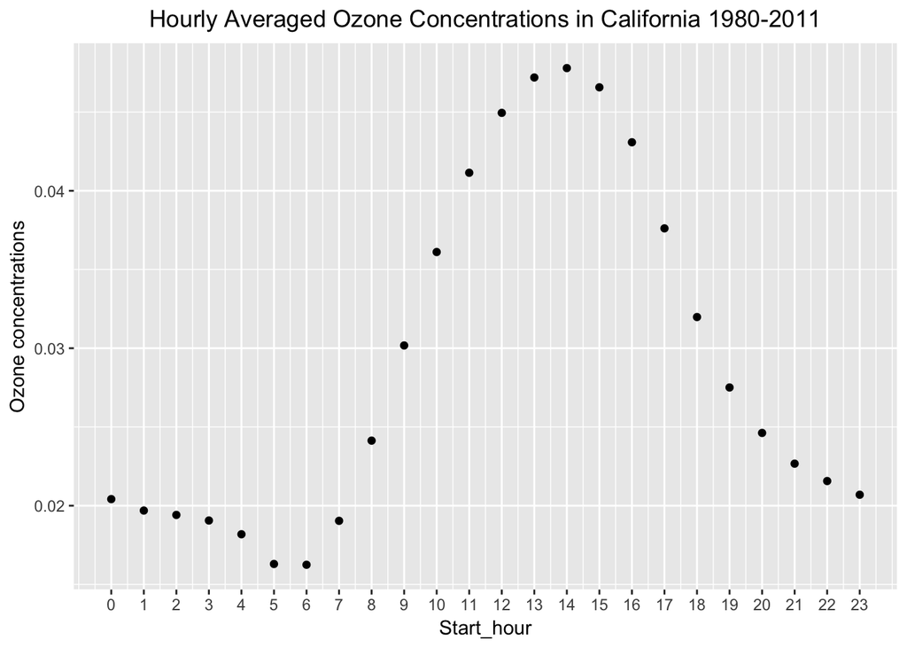

```r
hourly <- o3.filelist %>%
  rbindlist() %>%
  group_by(start_hour) %>%
  summarize(o3 = mean(obs, na.rm = TRUE))
ggplot(data=hourly)+
  geom_point(mapping = aes(x = start_hour, y= o3))+
  scale_x_continuous(breaks=hourly$start_hour)+
  ggtitle("Hourly Averaged Ozone Concentrations in California 1980-2011")+
  theme(plot.title = element_text(hjust = 0.5))+
  labs(
       x = "Start_hour",
        y = "Ozone concentrations"
)
```

8.95 site names in the CA air quality location dataset “Site Name” contain “San” or “Santa”.

```r
library(readxl)
setwd("/Users/zhongyueluan/es2018hw4")
loc <- read_excel("location.xls")
loc
```

| Location | Site | Site Name | Short Name | AIRS Site | AQD Site | County | County Abbr | County Name | Basin | Basin Name | District | District Name | PA8 | PA8 Name | State | MSA | MSA Name | AQCR | Urban Area | City | Address | Zip Code | Lat Degrees | Lat Minutes | Lat Seconds | Latitude | Long Degrees | Long Minutes | Long Seconds | … |
| --- | --- | --- | --- | --- | --- | --- | --- | --- | --- | --- | --- | --- | --- | --- | --- | --- | --- | --- | --- | --- | --- | --- | --- | --- | --- | --- | --- | --- | --- | --- |
| 2001 | 2001 | Citrus Heights-Sunrise Blvd | Citrus_Hghts | 060670001 | 3400293 | 34 | SAC | Sacramento | SV | Sacramento Valley | SAC | Sacramento County APCD | SMA8 | Sacramento Metropolitan Area | CA | 6920 | Sacramento | 28 | 6920 | 13588 | 7400 Sunrise Blvd | 95610 | 38 | 41 | 56.00 | 38.69889 | 121 | 16 | 15.99 | … |
| 2007 | 2007 | McCloud-Minnesota | McCloud-Minn | 060930002 | 4700867 | 47 | SIS | Siskiyou | NEP | Northeast Plateau | SIS | Siskiyou County APCD | NEP8 | Northeast Plateau | CA | 0 | Not in a MSA | 27 | 0 | 44784 | Minnesota Avenue | 35 | 41 | 16 | 15.99 | 41.27111 | 121 | 52 | 18.99 | … |
| 2008 | 2008 | El Capitan Beach | El_Capitan_B | 060830008 | 4200370 | 42 | SB | Santa Barbara | SCC | South Central Coast | SB | Santa Barbara County APCD | SB8 | Santa Barbara | CA | 7480 | Santa Barbara-Santa Maria-Lompoc | 32 | 7479 | 69070 | Location Approximate | 93117 | 34 | 27 | 44.00 | 34.46222 | 120 | 1 | 32.99 | … |
| 2011 | 2011 | Eureka-Fort Avenue | Eureka-FtAve | NA | 1200522 | 12 | HUM | Humboldt | NC | North Coast | NCU | North Coast Unified AQMD | NC8 | North Coast | CA | 0 | Not in a MSA | 0 | 0 | 23042 | Address Not Known | 95501 | 40 | 48 | 7.00 | 40.80194 | 124 | 9 | 46.99 | … |
| 2012 | 2012 | Fresno-Cal State #2 | Fresno-ClSt2 | 060190241 | 1000241 | 10 | FRE | Fresno | SJV | San Joaquin Valley | SJV | San Joaquin Valley Unified APCD | SJV8 | San Joaquin Valley | CA | 2840 | Fresno | 31 | 2840 | 27000 | East Shaw Avenue and North Maple Avenue | 93710 | 36 | 48 | 48.99 | 36.81361 | 119 | 44 | 24.99 | … |
| 2013 | 2013 | Fresno-Drummond Street | Fresno-Drmnd | 060190007 | 1000244 | 10 | FRE | Fresno | SJV | San Joaquin Valley | SJV | San Joaquin Valley Unified APCD | SJV8 | San Joaquin Valley | CA | 2840 | Fresno | 31 | 2840 | 27000 | 4706 East Drummond Avenue | 93725 | 36 | 42 | 19.99 | 36.70555 | 119 | 44 | 28.98 | … |
| 2014 | 2014 | Petaluma-Payran | Petaluma-Pyr | 060971002 | 4900883 | 49 | SON | Sonoma | SFB | San Francisco Bay Area | BA | Bay Area AQMD | SFB8 | San Francisco Bay Area | CA | 7500 | Santa Rosa | 30 | 0 | 56784 | 301 Payran Street | 94952 | 38 | 13 | 58.80 | 38.23300 | 122 | 38 | 9.60 | … |
| 2016 | 2016 | Carmel Valley-Ford Road | Carm_Val-Frd | 060530002 | 2700550 | 27 | MON | Monterey | NCC | North Central Coast | MBU | Monterey Bay Unified APCD | NCC8 | North Central Coast | CA | 7120 | Salinas | 25 | 0 | 11320 | 35 Ford Road | 93924 | 36 | 28 | 54.83 | 36.48190 | 121 | 43 | 59.88 | … |
| 2023 | 2023 | Independence-8 miles NNW-Pump #1 | Independ-8mi | 060270006 | 1400701 | 14 | INY | Inyo | GBV | Great Basin Valleys | GBU | Great Basin Unified APCD | GBV8 | Great Basin Valleys | CA | 0 | Not in a MSA | 23 | 0 | 36350 | Location Approximate | 93526 | 36 | 54 | 17.99 | 36.90500 | 117 | 45 | 39.99 | … |
| 2024 | 2024 | Burlingame-Burlingame Avenue | Burlngme-Ave | 060810002 | 4100545 | 41 | SM | San Mateo | SFB | San Francisco Bay Area | BA | Bay Area AQMD | SFB8 | San Francisco Bay Area | CA | 7360 | San Francisco | 30 | 7360 | 9066 | 1229 Burlingame Avenue | 94010 | 37 | 35 | 2.39 | 37.58400 | 122 | 21 | 54.00 | … |

[output cut: 911 more lines]

```r
colnames(loc)[1] <- "site"
toMatch <- c("San","Santa")
sum(str_detect(unique(loc$`Site Name`), paste(toMatch,collapse="|")))
```

```
## [1] 95
```

9.23 sites do not have a complete address (full street address and zip code).

```r
sum(is.na(loc$Address))
```

```
## [1] 120
```

```r
sum(is.na(loc$`Zip Code`))
```

```
## [1] 142
```

```r
length(unique(loc[is.na(loc$Address) | is.na(loc$`Zip Code`),]$Site))
```

```
## [1] 23
```

10.The semi join() differ from an inner join() in only keeping the columns from x while inner join() keeping all columns from x and y.

11.My function Annual_mean_median_max_min() is to calculate the annual mean, median, max and min of all sites that have either of the two special strings in the Site Name. Input x is the original list data. Input y and z is the special strings. In this case, x is o3.filelist. y and z are “San” or “Santa”.

```r
  Annual_mean_median_max_min <- function(x,y,z){
    annual <- x %>%
  rbindlist() %>%
  group_by(site = as.factor(site))%>%
  semi_join(filter(loc, grepl(paste(c(y,z), collapse="|"), loc$`Site Name`)), by = "site")%>%
                  mutate(year = format(date, "%Y")) %>%
                  group_by(site,year) %>%
   summarize(annual_mean = mean(obs, na.rm = TRUE), annual_median = median(obs, na.rm = TRUE),annual_max = max(obs, na.rm = TRUE),annual_min = min(obs, na.rm = TRUE) )
    annual
    }
Annual_mean_median_max_min(o3.filelist,"San","Santa")
```

| site | year | annual_mean | annual_median | annual_max | annual_min |
| --- | --- | --- | --- | --- | --- |
| 2040 | 1980 | 0.031031966 | 0.0300000 | 0.1800000 | 0.0000000 |
| 2040 | 1981 | 0.030796922 | 0.0300000 | 0.2000000 | 0.0000000 |
| 2040 | 1982 | 0.027044510 | 0.0200000 | 0.2300000 | 0.0000000 |
| 2040 | 1983 | 0.028511335 | 0.0300000 | 0.2800000 | 0.0000000 |
| 2040 | 1984 | 0.029268142 | 0.0300000 | 0.2800000 | 0.0000000 |
| 2040 | 1985 | 0.033870216 | 0.0300000 | 0.2200000 | 0.0000000 |
| 2040 | 1986 | 0.031238972 | 0.0300000 | 0.1500000 | 0.0000000 |
| 2040 | 1987 | 0.030707729 | 0.0300000 | 0.1700000 | 0.0000000 |
| 2040 | 1988 | 0.032104747 | 0.0300000 | 0.2200000 | 0.0000000 |
| 2040 | 1989 | 0.033239811 | 0.0300000 | 0.2300000 | 0.0000000 |

[output cut: 625 more lines]

12.My function annual_daily_mean() is to caculate the annual daily mean. Apply that function to Merced County. The annual daily mean of o3 for Merced County is shown in the dataframe “annual_daily_mean”.

```r
annual_daily_mean <- function (x,y){
  annual_daily_mean <- x %>%
  semi_join(subset(loc,loc$`County Name`==y), by = "site")%>%
                  mutate(year = format(date, "%Y")) %>%
                  group_by(year) %>%
   summarize(annual_daily_mean = mean(o3, na.rm = TRUE))
 annual_daily_mean
}
annual_daily_mean(daily,"Merced")
```

| year | annual_daily_mean |
| --- | --- |
| 1981 | 0.01871157 |
| 1982 | 0.03769584 |
| 1991 | 0.02926434 |
| 1992 | 0.03090583 |
| 1993 | 0.02979369 |
| 1994 | 0.03160586 |
| 1995 | 0.03426798 |
| 1996 | 0.03382698 |
| 1997 | 0.03192600 |
| 1998 | 0.03554296 |

[output cut: 13 more lines]